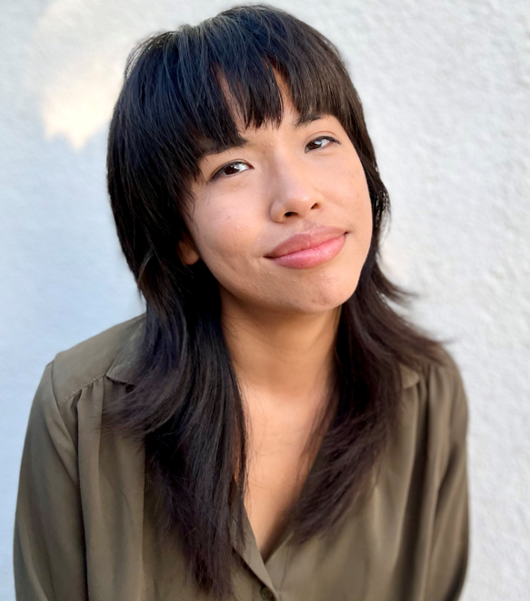

# kat chia

**Hi, I’m Kat and I’m on the job market!**

I’m a Cognitive Science Ph.D. turned product-minded research scientist, passionate about building AI-powered tools that are intuitive, impactful, and responsible.

Most recently at Cangrade, I led the development of several ML and LLM-driven products where user experience quality and product intuition were my goal. I specialize in identifying friction points in complex systems, testing and iterating on flows, and collaborating across teams. I also bring a Responsible AI lens to every stage of my projects.

At [Cangrade](https://www.cangrade.com/), I led the development of multiple products that combine machine learning, large language models (LLMs), and user-centered design to streamline hiring for enterprise clients:

- [Jules AI Copilot](https://www.myjules.ai/): A generative AI chatbot for enterprise hiring workflows and personal use with safety guardrails built in.
- Resume Ranker: A generative AI tools for evaluating resumes without introducing bias. I led every stage from prototyping, cross-functional testing, and assessing product-market fit.
- Position-Specific Assessments: A patent-pending tool that sues LLMs to auto-generate custom skills assessments from job descriptions. I designed it to reduce recruiter effort while adding standards for transparency and the ability to audit.

My work bridges research and product, combining rigorous experimentation with strategic product thinking. I collaborate closely with engineers, customer success, and designers to define requirements, shape roadmaps, and bring AI products to market.

I have my PhD in Cognitive Science from [Florida State University](https://psy.fsu.edu/), where I worked with the unparalleled [Dr. Michael Kaschak](https://psy.fsu.edu/php/people/people.php?_tr=1_5#), investigating linguistic alignment and language production.

I taught quite a bit at Florida State University as well! I was the instructor for 5 different courses ranging from 25-250 students a class.

I also spent time at **IBM Research**, applying linguistic data to healthcare use cases.

This website was made using the `distill` and `postcards` packages in R. It is currently being hosted on [**Github**](https://github.com/katchia/katchia.com) and **Netlify**.